# Datos Solidarios con R: Primeros pasos

Análisis y visualización de datos para el sector solidario en Colombia

En este primer tutorial enseñará a l@s participantes del curso a usar la interfase de R Studio para realizar tareas básicas.

## 🧮 Usando R como calculadora

En su funcionalidad más básica R puede ser utilizada como una calculadora tradicional.

```r
520*40
```

```
## [1] 20800
```

```r
(120-75)/2
```

```
## [1] 22.5
```

## 📝 Objectos, Funciones y Paquetes

Una parte importante de programar usando lenguaje R son: *los objectos*, *las funciones* y *los paquetes*. A continuación, se explica que son cada uno de estos elementos.

### Objectos

*Un objeto* es cualquier cosa, que queremos que R almacene para poder acceder a él. Puede ser desde un único valor hasta una colección de valores, un conjunto de datos, una función o incluso una lista de otros objetos. *La única limitación para los objetos* es que **cada uno debe tener un nombre único**, que se utiliza para llamarlo.

Para crear un objeto, utilizamos el operador de asignación (= o <-), donde colocamos el nombre del objeto que queremos crear a la izquierda de la flecha y el objeto en sí a la derecha.

```r
valor = 10
value <- 50
suma = valor - value
suma
```

```
## [1] -40
```

```r
valor = 80
suma = valor - value
suma
```

```
## [1] 30
```

Dentro de la categoría de objectos, uno de ellos tiene un destaque especial: *data frames*. En R, un *data frame* es una estructura de datos fundamental y ampliamente utilizada para almacenar datos tabulares. Puede conceptualizarse como una hoja de cálculo o una tabla en una base de datos, con filas que representan observaciones y columnas que representan variables.

```r
base <- data.frame( nombre = c("Cooperativa A", "Cooperativa B",
                               "Cooperativa C", "Cooperativa D",
                               "Cooperativa E", "Cooperativa F"),
                    ingresos = c(120000, 450000, 180000, 250000,
                                 400000, 150000))
```

```r
base
```

| nombre | ingresos |
| --- | --- |
| Cooperativa A | 120000 |
| Cooperativa B | 450000 |
| Cooperativa C | 180000 |
| Cooperativa D | 250000 |
| Cooperativa E | 400000 |
| Cooperativa F | 150000 |

### Funciones

Mientras que los objetos son todo lo que almacenamos en R, las **funciones** son todo lo que hacemos en R. Las funciones son bloques de código autónomos diseñados para tomar uno o varios objetos y realizar tareas específicas; ellas reciben entradas (argumentos), las procesan y devuelven una salida.

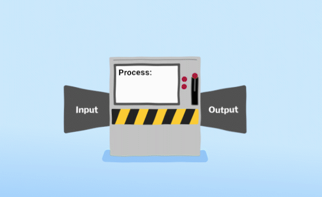

Fuente: INE Chile

Como ejemplo de funciones que vienen incorporadas en *lenguaje de R Base*, podemos mencionar las siguientes:

- Suma

```r
sum(base$ingresos)
```

```
## [1] 1550000
```

- Média

```r
mean(base$ingresos)
```

```
## [1] 258333.3
```

Si no estamos familiarizados con una función siempre podemos pedir ayuda y consultar la documentación del paquete, usando el siguiente comando:

```r
#help("mean")
```

### Paquetes

Los **paquetes en R** son colecciones de funciones, datos y documentación agrupadas en un formato estandarizado. Amplían las capacidades de R al proporcionar funcionalidades especializadas más allá de la instalación base. Los paquetes suelen almacenarse en un directorio llamado “biblioteca” dentro del entorno de R.

#### 🌌 **Tidyverse**

Tidyverse es una colección de paquetes de R diseñados para que los flujos de trabajo de ciencia de datos sean más consistentes, eficientes y amenos. Abarca un conjunto de paquetes que comparten una filosofía de diseño, gramática y estructuras de datos comunes, centrados principalmente en los principios de “datos ordenados”.

[figure not shown]

Fuente: Rpubs

*Paquetes principales*:

Incluye paquetes esenciales para diversas tareas de ciencia de datos:

*dplyr*: Para la manipulación de datos (p. ej., filter(), mutate(), group_by(), summary()).

*ggplot2*: Para la visualización de datos, creando gráficos estadísticos de alta calidad.

*tidyr*: Para ordenar datos, transformándolos entre formatos anchos y largos (p. ej., pivot_wider(), pivot_longer()).

*readr*: Para importar datos desde varios formatos de archivo (p. ej., read_csv(), read_tsv()).

*purrr*: Para la programación funcional, facilitando el trabajo con listas y la aplicación iterativa de funciones.

*stringr*: Para la manipulación de secuencias de caracteres.

*forcats*: Para trabajar con factores (variables categóricas).

*Operador de canalización (%>%)*: Tidyverse utiliza ampliamente el operador de canalización del paquete magrittr, que permite encadenar múltiples operaciones de forma legible e intuitiva.

A continuación, realizaremos la instalación del paquete `tidyverse` y su activación para comenzar a usarlo en el próximo tutotial. Para lo cual, debemos usar el siguiente comando:

```r
#install.packages("tidyverse")
library(tidyverse)
```

## 👣 Próximos pasos

En el oróximo tutorial aprenderemos:

- Cómo limpiar y procesar los datos de una base
- Calcular estadísticas básicas
- Crear gráficos

#### 📜 Licencia

Material educativo diseñado para el curso **Datos Solidarios con R**.  
© 2025 — Yulieth Martínez Villalba.